# Implementação dos algoritmos k-Nearest-Neighbors e k-Means e avaliação de sua aplicação ao dataset Iris

### Introdução à Inteligência Artificial

**Nome:** André Luiz Moreira Dutra

**Matrícula:** 2019006345

## Introdução

O aprendizado de máquina é a principal técnica de inteligência artificial utilizada atualmente, e um dos seus principais usos é em ciência de dados. Neste contexto, este trabalho visa implementar e analisar o desempenho de dois algoritmos relativamente simples de aprendizado: o k-Nearest Nighbors, um algoritmo de classificação baseado em aprendizado supervisionado, e o k-Means, um algoritmo de agrupamento baseado em aprendizado não supervisionado.

Ambos os algoritmos serão usados para a análise da base de dados Iris, um dataset clássico utilizado no estudo de algoritmos de inteligência artificial. O banco é constituído por informações sobre as três espécies de flores do gênero Iris: Iris setosa, Iris virginica e Iris versicolor. O dataset contém 150 instâncias multivariadas, sendo 50 de cada espécie de Iris, e cada uma contém os dados de comprimento e largura das pétalas e sépalas das flores da instância.

Desse modo, para o primeiro algoritmo, os dados do Iris foram organizados em duas tabelas: *iris_train* e *iris_test*. *iris_train* será usada para o treinamento do algoritmo, sendo composta por 120 linhas, e as demais 30 linhas serão usadas como teste do algoritmo, compondo *iris_test*. Ambas as tabelas contêm as colunas *sepal_length*, *sepal_width*, *petal_length* e *petal_width*, contendo as métricas de cada flor, e *species*, contendo a espécie à qual a flor pertence.

**Obs:** A execução correta dos códigos requer que os arquivos do dataset Iris fornecidos estejam presentes no ambiente do notebook com os nomes "iris_aleatorio.csv", "iris_treino.csv" e "iris_teste.csv".

```python
import pandas as pd
import numpy as np
import matplotlib.pyplot as plt
import seaborn as sns
```

```python
columns = ['sepal_length','sepal_width','petal_length','petal_width','species']
iris_train = pd.read_csv('iris_treino.csv', sep=';', header=None, names=columns)
iris_test = pd.read_csv('iris_teste.csv', sep=';', header=None, names=columns)
display(iris_train.head())
display(iris_test.head())
```

|  | sepal_length | sepal_width | petal_length | petal_width | species |
| --- | --- | --- | --- | --- | --- |
| 0 | 4.6 | 3.2 | 1.4 | 0.2 | Iris-setosa |
| 1 | 6.3 | 3.4 | 5.6 | 2.4 | Iris-virginica |
| 2 | 6.7 | 3.1 | 5.6 | 2.4 | Iris-virginica |
| 3 | 7.9 | 3.8 | 6.4 | 2.0 | Iris-virginica |
| 4 | 7.7 | 3.8 | 6.7 | 2.2 | Iris-virginica |

|  | sepal_length | sepal_width | petal_length | petal_width | species |
| --- | --- | --- | --- | --- | --- |
| 0 | 5.4 | 3.4 | 1.7 | 0.2 | Iris-setosa |
| 1 | 6.3 | 2.8 | 5.1 | 1.5 | Iris-virginica |
| 2 | 5.7 | 2.9 | 4.2 | 1.3 | Iris-versicolor |
| 3 | 6.3 | 3.3 | 6.0 | 2.5 | Iris-virginica |
| 4 | 7.7 | 2.6 | 6.9 | 2.3 | Iris-virginica |

## Parte 1: k-Nearest Neighbors

O k-Nearest Neighbors, ou k-NN, é um algoritmo de classificação utilizado para prever uma determinada característica discreta de uma instância de dados à partir da generalização de um conjunto de treino semelhante fornecido. No caso da base Iris, o objetivo do k-NN é prever, a partir das dimensôes das pétalas e das sépalas, a espécie de uma instância qualquer, à partir das informações da base usadas para o treino do algoritmo.

O k-Nearest Neighbors é, desse modo, um tipo de algoritmo baseado em aprendizado supervisionado. O resultado esperado do algoritmo, a espécie da planta, já é conhecido nos dados, e as classificações do conjunto de treino são usadas para aperfeiçoar o resultado da classificação da instância.

O princípio do k-Nearest Neighbors é bem simples. Os dados contínuos da base, dos quais a classe será predita, podem ser vistos como pontos no espaço. No caso da base Iris, as informações das pétalas e das sépalas formariam um conjunto de pontos em um espaço tetradimensional. Desse modo, dada uma base de treino, uma instância e um determinado valor de k, o k-Nearest Neighbors seleciona os k pontos da base mais próximos da instância, a partir de alguma métrica de distância, e atribui à instância analisada a classe que ocorre mais vezes entre os k. No caso da base Iris, ele escolheria, dentre as três, a espécie a que pertencem a maioria dos elementos entre os k escolhidos e atribuiria à flor que se quer classificar.

O código a seguir é uma implementação do k-NN. Ele utiliza como métrica de distância a distância euclidiana, definida na função *euclidean*. Ela simplesmente toma duas linhas da tabela, filtra apenas as colunas de dados, sobre as quais a distância será calculada, e calcula a distância entre os pontos fazendo a norma vetorial da diferença dos pontos.

O k-NN em si está implementado na função *kNN_classify*, e recebe como entrada o número de vizinhos *k*, que deve ser um inteiro, a base de treino *data*, que deve ser uma tabela na qual uma das colunas é a categoria de classificação e as demais os demais dados, e a instância *instance* a ser testada, que deve seguir o mesmo modelo da tabela *data* (exceto pela coluna de categoria). Opcionalmente, o nome da coluna na qual a categoria a ser classificada pode ser fornecida no parâmetro *category_col*. Por padrão, se ela não for fornecida, o algoritmo seleciona a última coluna da tabela *data*

```python
def euclidean(x, y, data_cols):
    return np.linalg.norm(x[data_cols]-y[data_cols])

def kNN_classify(k, data, instance, category_col = None):
    if category_col is None:
        category_col = data.columns[-1]

    data_cols = [col for col in data.columns if col != category_col]

    k_nearest = data.head(k).copy()
    k_nearest['dist'] = [euclidean(row, instance, data_cols) for _,row in k_nearest.iterrows()]

    idx_max = k_nearest['dist'].idxmax()
    max_distance = k_nearest['dist'][idx_max]

    for _, row in data.iterrows():
        distance = euclidean(row, instance, data_cols)

        if distance >= max_distance:
            continue

        row['dist'] = distance
        k_nearest.loc[idx_max] = row

        idx_max = k_nearest['dist'].idxmax()
        max_distance = k_nearest['dist'][idx_max]

    return k_nearest[category_col].mode()[0]
```

O código em si funciona de forma muito simples e intuitiva. Ele primeiro escolhe k linhas quaisquer da base para ser os k-vizinhos da instância, e para cada uma calcula a distância euclidiana dela à instância dada. Dentre elas, é selecionado o índice da linha mais distante entre as k, em conjunto com o valor de sua distância.

O algoritmo então itera por cada linha da base, calculando sua distância euclidiana da instância e comparando com a distância do vizinho mais distante entre os k. Se ela estiver mais próxima da instância que ele, a linha substitui o vizinho mais distante no conjunto dos k vizinhos e o novo vizinho mais distante é recalculado. Após passar por todas as linhas, o algoritmo retorna a moda da coluna de categorias dos vizinhos, ou seja, a categoria que ocorre com mais frequência entre os k vizinhos mais próximos.

Observe que o algoritmo sempre encontra os k-vizinhos mais próximos. Isso ocorre por dois motivos. Primeiro, um ponto entra no conjunto dos k se, e somente se ele estiver mais próximo que o mais distante entre eles, então um ponto mais distante testado nunca é adicionado no conjunto e um ponto mais próximo testado nunca é ignorado do conjunto. Segundo, todos os pontos da base são testados. Assim, apenas pontos mais próximos são adicionados entre os k, resultando nos k-vizinhos mais próximos.

Um ponto muito importante do k-NN é o fato de seu funcionamento depender da escolha do k adequado para a base utilizada. Assim, tendo implementado o algoritmo, precisamos testar sua eficácia, levando em consideração principalmente a escolha de diferentes valores de k. Para isso, usaremos a divisão do banco mencionada anteriormente. 120 linhas serão utilizadas como treino e as demais 30 como teste.

Uma forma de observar o desempenho do algoritmo é por meio de uma matriz de confusão. Nela, as linhas e colunas contêm as classes da classificação, sendo as linhas o valor real e as colunas o valor predito pelo algoritmo. Assim, para cada instância do conjunto de teste, o k-NN é executado e seu resultado, em conjunto com a classe real já existente na base, determinam a que posição da matriz de confusão a instância pertencerá. A seguinte função foi utilizada para Calcular a matriz de confusão dados o k, a base de treino e a base de teste, sendo a coluna de categorias opcional, como no anterior:

```python
def kNN_test_data(k, train_data, test_data, category_col = None):
    if category_col is None:
        category_col = train_data.columns[-1]

    categories = sorted(train_data[category_col].unique())

    confusion = pd.DataFrame(0, index = categories, columns = categories)

    for _, row in test_data.iterrows():
        predicted = kNN_classify(k, train_data, row, category_col)
        real = row[category_col]
        confusion.loc[real,predicted] += 1

    confusion.index = pd.MultiIndex.from_product([['Real'],categories])
    confusion.columns = pd.MultiIndex.from_product([['Previsto'],categories], names = ['','k = {}'.format(k)])

    return confusion
```

Com isso, o algoritmo será testado para o iris_train e o iris_test com quatro valores de k: 2, 8, 19 e 32. Dentre estes, o valor de minha escolha foi 19, simplesmente por ser um valor intermediário entre 8 e 32, a maior lacuna entre os valores dados. Para cada k, podemos executar o algoritmo e gerar as matrizes de confusão:

```python
ks = [2, 8, 19, 32]
confusions = [kNN_test_data(k,iris_train,iris_test) for k in ks]

for c in confusions:
  display(c)
  print('')
```

|  | k = 2 | Previsto Iris-setosa | Previsto Iris-versicolor | Previsto Iris-virginica |
| --- | --- | --- | --- | --- |
| Real | Iris-setosa | 9 | 0 | 0 |
|  | Iris-versicolor | 0 | 12 | 0 |
|  | Iris-virginica | 0 | 2 | 7 |

|  | k = 8 | Previsto Iris-setosa | Previsto Iris-versicolor | Previsto Iris-virginica |
| --- | --- | --- | --- | --- |
| Real | Iris-setosa | 9 | 0 | 0 |
|  | Iris-versicolor | 0 | 12 | 0 |
|  | Iris-virginica | 0 | 1 | 8 |

|  | k = 19 | Previsto Iris-setosa | Previsto Iris-versicolor | Previsto Iris-virginica |
| --- | --- | --- | --- | --- |
| Real | Iris-setosa | 9 | 0 | 0 |
|  | Iris-versicolor | 0 | 12 | 0 |
|  | Iris-virginica | 0 | 0 | 9 |

|  | k = 32 | Previsto Iris-setosa | Previsto Iris-versicolor | Previsto Iris-virginica |
| --- | --- | --- | --- | --- |
| Real | Iris-setosa | 9 | 0 | 0 |
|  | Iris-versicolor | 0 | 12 | 0 |
|  | Iris-virginica | 0 | 1 | 8 |

As matrizes acima trazem resultados muito interessantes para cada k. O mais evidente é a matriz de confusão para k = 19, que não apresentou erro nenhum, indicando uma classificação perfeita.

Embora a tabela mostre os erros e acertos do algoritmo para cada classe, a interpretação desses dados é de certa forma abstrata e dependente do observador. Precisamos, assim, de métricas que tragam interpretações mais concretas e precisas sobre as informações mostradas na matriz de confusão.

Por essa razão, para cada matriz, foram calculados os valores de acurácia, precisão, revocação e F1:

- A **acurácia** é uma métrica geral da matriz, e mede a porcentagem de instâncias identificadas corretamente, ou seja, do total, quantas se encontram na diagonal da matriz.
- A **precisão** é uma métrica aplicada a cada classe, e mede a porcentagem de instâncias previstas corretamente dentre todas as previsões da classe. Assim, uma precisão baixa indica que muitas instâncias fora da classe real foram preditas como pertencentes àquela classe, ou seja, um alto número de falsos positivos.
- A **revocação** é uma métrica aplicada a cada classe, e mede a porcentagem de instâncias previstas corretamente dentre todas as instâncias reais da classe. Assim, uma revocação baixa indica que muitas instâncias da classe real não foram preditas corretamente, ou seja, um alto número de falsos negativos.
- O **F1** é uma forma de observar a precisão e a revocação de cada classe simultaneamente, fazendo uma média harmônica entre as duas. Uma das principais características da média harmônica é que se um dos elementos for nulo, a média é nula também. Assim, para que uma classe tenha um bom F1 ela precisa ter tanto uma precisão quanto uma revocação boa.

O cálculo das quatro métricas é feito nas seguintes funções:

```python
def accuracy(confusion):
    matrix = confusion.to_numpy()
    acc = matrix.trace()/matrix.sum()
    return pd.DataFrame(acc, index=['Acurácia'], columns = confusion.columns.droplevel(0))

def precision(confusion):
    diags = pd.DataFrame([np.diag(confusion)], index=['Precisão'], columns=confusion.columns.droplevel(0))
    predicts = confusion.sum().to_frame().transpose()

    predicts.columns = predicts.columns.droplevel(0)
    predicts.index = ['Precisão']
    return diags/predicts

def recall(confusion):
    diags = pd.DataFrame([np.diag(confusion)], index=['Revocação'], columns=confusion.columns.droplevel(0))
    reals = confusion.sum(axis=1).to_frame().transpose()

    reals.columns = reals.columns.droplevel(0)
    reals.index = ['Revocação']
    return diags/reals

def f1(confusion):
    p = precision(confusion)
    p.index = [0]
    r = recall(confusion)
    r.index = [0]

    f_1 = 2*p*r/(p+r)
    f_1.index = ['F1']
    return f_1
```

Para cada uma das quatro matrizes de confusão geradas para cada k, foram calculados os valores de acurácia, precisão, revocação e F1. Observe os valores obtidos (a acurácia é relativa à tabela inteira, mas foi repetida nas classes para facilitar a visualização):

```python
general_stats = [pd.concat([accuracy(confusion), precision(confusion), recall(confusion), f1(confusion)]) for confusion in confusions]

for k, confusion in zip(ks,confusions):
  general_stat = pd.concat([accuracy(confusion), precision(confusion), recall(confusion), f1(confusion)])
  general_stat.columns.name = 'k = {}'.format(k)
  display(general_stat)
  print('')
```

| k = 2 | Iris-setosa | Iris-versicolor | Iris-virginica |
| --- | --- | --- | --- |
| Acurácia | 0.933333 | 0.933333 | 0.933333 |
| Precisão | 1.000000 | 0.857143 | 1.000000 |
| Revocação | 1.000000 | 1.000000 | 0.777778 |
| F1 | 1.000000 | 0.923077 | 0.875000 |

| k = 8 | Iris-setosa | Iris-versicolor | Iris-virginica |
| --- | --- | --- | --- |
| Acurácia | 0.966667 | 0.966667 | 0.966667 |
| Precisão | 1.000000 | 0.923077 | 1.000000 |
| Revocação | 1.000000 | 1.000000 | 0.888889 |
| F1 | 1.000000 | 0.960000 | 0.941176 |

| k = 19 | Iris-setosa | Iris-versicolor | Iris-virginica |
| --- | --- | --- | --- |
| Acurácia | 1.0 | 1.0 | 1.0 |
| Precisão | 1.0 | 1.0 | 1.0 |
| Revocação | 1.0 | 1.0 | 1.0 |
| F1 | 1.0 | 1.0 | 1.0 |

| k = 32 | Iris-setosa | Iris-versicolor | Iris-virginica |
| --- | --- | --- | --- |
| Acurácia | 0.966667 | 0.966667 | 0.966667 |
| Precisão | 1.000000 | 0.923077 | 1.000000 |
| Revocação | 1.000000 | 1.000000 | 0.888889 |
| F1 | 1.000000 | 0.960000 | 0.941176 |

É notável que quase todas as métricas calculadas em cada matriz ficaram acima de 80% ou 90%, indicando uma alta eficácia do algoritmo para todos os ks escolhidos. Novamente podemos ver os resultados perfeitos do k = 19, com todas as métricas com valor máximo.

Os dados foram organizados em gráficos para facilitar a observação, observando a progressão de cada métrica com o valor de k para cada classe:

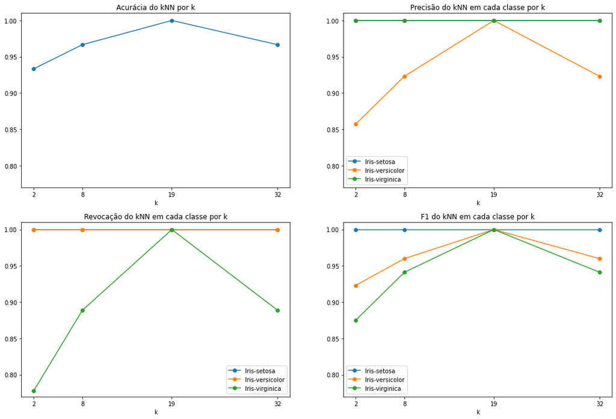

```python
ks = [2, 8, 19, 32]

accu = pd.concat([accuracy(confusion) for confusion in confusions]).iloc[:,0]
prec = pd.concat([precision(confusion) for confusion in confusions])
rec = pd.concat([recall(confusion) for confusion in confusions])
F1 = pd.concat([f1(confusion) for confusion in confusions])

fig, axs = plt.subplots(2,2,figsize = (18,12))

accu.index = ks
ax = axs[0][0]
accu.plot(ax = ax, marker='o', legend=False)
ax.set_xticks(ks)
ax.set_ylim(0.77,1.01)
ax.set_title('Acurácia do kNN por k')
ax.set_xlabel('k')

prec.index = ks
ax = axs[0][1]
prec.plot(ax = ax, marker='o')
ax.set_xticks(ks)
ax.set_ylim(0.77,1.01)
ax.set_title('Precisão do kNN em cada classe por k')
ax.set_xlabel('k')

rec.index = ks
ax = axs[1][0]
rec.plot(ax = ax, marker='o')
ax.set_xticks(ks)
ax.set_ylim(0.77,1.01)
ax.set_title('Revocação do kNN em cada classe por k')
ax.set_xlabel('k')

F1.index = ks
ax = axs[1][1]
F1.plot(ax = ax, marker='o')
ax.set_xticks(ks)
ax.set_ylim(0.77,1.01)
ax.set_title('F1 do kNN em cada classe por k')
ax.set_xlabel('k')

plt.show()
```

É notável que o k = 19 de fato teve os melhores resultados, alcançando os valores máximos em todas as métricas para todas as classes. Podemos observar, assim, a tendência à formação de um pico em torno de k = 19. O problema da escolha do k se dá principalmente porque a escolha de um k muito pequeno pode ser insuficiente para extrair as informações necessárias da base, enquanto a escolha de um k muito grande pode tornar os resultados muito dependentes da base e com isso muito difíceis de generalizar para outros dados aleatórios. Assim, o k ideal parece ser k = 19 ou estar muito próximo dele.

No entanto, os outros valores de k não tiveram resultados muito piores. As matrizes de k = 8 e k = 32 foram idênticas e só houve uma identificação incorreta nelas, enquanto para k = 2 só houve duas identificações incorretas. No entanto, valores absolutos podem enganar, já que estamos trabahando com apenas 30 instâncias de teste.

As métricas calculadas são especialmente importantes nesse sentido, já que elas são porcentagens relativas ao total, e não valores absolutos.

Observando a acurácia, que calcula o desempenho geral dos algoritmos, todos eles tiveram um desempenho geral muito alto, com mesmo o pior k, k = 2, estando acima de 90%.

Observando as demais métricas, que diferem entre as classes, podemos observar um comportamento muito característico em cada classe. Notavelmente, as instâncias de Iris setosa tiveram precisão, revocação e F1 máximos em para todos os valores de k. Isso aponta para um possivel distanciamento dos pontos de Iris setosa dos demais, facilitando a classificação. Isso será observado com mais detalhes no próximo algoritmo, o k-Means.

Por fim, o F1, que é a média harmônica das duas, indica que o efeito da baixa revocação na Iris virginica foi mais intenso que o efeito da baixa precisão na Iris versicolor. Isso se dá principalmente pela distribuição desigual das classes nas instâncias de teste.

Note que as Iris setosa foram todas identificadas corretamente, então todos os falsos negativos da Iris virginica foram instâncias de Iris virginica sendo identificadas como Iris versicolor. No entanto, o conjunto de teste é constituído por 12 instâncias de Iris versicolor e 9 instâncias de Iris virginica, então o efeito de identificar uma Iris virginica errada entre 9 é mais intenso do que o de identificar como Iris versicolor 12 corretamente e uma erroneamente.

Fica evidente, assim, a importância do uso das métricas para identificar efeitos positivos e negativos em cada classe que não seriam captados apenas pela acurácia, mesmo que elas estejam divididas de forma desigual.

## Parte 2: k-Means

Além de realizar classificações, algoritmos de aprendizado podem também obter novas informações ainda não conhecidas sobre os dados. Este é o princípio do aprendizado não-supervisionado, que, ao contrário do aprendizado supervisionado, não trabalha utilizando resultados esperados para o conjunto de treino, já que estes resultados geralmente ainda não são conhecidos. Assim, algoritmos de aprendizado não-supervisionado geralmente analisam todo o conjunto de dados em busca de associações entre as instâncias.

Dentre estes algoritmos estão os algoritmos de agrupamento, que buscam agrupar os dados em conglomerados que compartilhem entre si informações semelhantes. No caso do dataset Iris, que estamos analisando, uma aplicação imediata do método seria tentar utilizá-lo para classificar as flores em grupos que correspondam às espécies, por exemplo.

O algoritmo de agrupamento que implementaremos será o k-Means. Seu funcionamento também é relativamente simples, e seu objetivo é, dada uma base de dados e um número k de grupos, dividí-la em k grupos de modo que pontos em um mesmo grupo estejam mais próximos entre si em relação aos demais.

Para isso, o k-Means começa selecionando k pontos aleatórios da base para cerem os centroides de cada grupo, e associando cada ponto da base ao grupo do centroide mais próximo a ele. O algoritmo então entra em um loop, no qual ele recalcula os centroides, fazendo a média dos pontos de cada grupo (vide o nome, k-Means), e reagrupando os pontos de acordo com o centroide mais próximo. Quando todos os pontos continuarem no mesmo grupo após uma iteração do loop, os grupos convergiram e o loop é quebrado, retornando os dados agrupados e os centroides gerados em cada grupo.

A implementação do k-means foi feita de forma muito semelhante à ideia principal, já que o próprio pandas fornece funções para realizar as ações no banco previstas pelo algoritmo.

Ele começa tomando k linhas aleatórias do banco por meio do sample, que serão os primeiros centroides. Ele então cria uma coluna *centroid* no banco e preenche o centroide mais próximo para cada linha. O cálculo do centroide mais próximo é feito pela função *nearest_centroid*, que, dada uma linha do banco e os centroides, seleciona o índice do centroide cuja distância euclidiana à linha é a menor por meio da função *min*.

Com o agrupamento inicial feito, o algoritmo define a flag points_change, que define o fluxo do loop, para True e entra em loop até que ela seja falsa, ou seja, nenhum ponto mudou. Ele então recalcula os centroides, muda points_changed para False e preenche novamente a coluna *centroid* com os centroides mais próximos de cada linha. Se o valor tiver mudado em relação ao anterior, mais uma iteração deve ser feita, então a flag é mudada para True novamente. Se após uma iteração nenhum ponto mudar, a flag estará com valor falso, o loop é quebrado e o conjunto agrupado e os centroides são retornados.

O recálculo dos centroides é feito na função *recalculate_centroids*. Como os centroides são simplesmente as médias de cada grupo, ela simplesmente faz um groupby na base pela coluna de centroides e tira a média de cada grupo, gerando os novos centroides.

Uma diferença notável entre este algoritmo e o k-NN é que ele não espera que os dados venham com a coluna de classes. Conforme discutido, o contexto de uso do algoritmo seria justamente o de descobrir uma coluna que divida os dados em classes, então se presume que ela não é conhecida.

```python
def nearest_centroid(row, centroids):
    x = row[row.index != 'centroid']
    idx, min_centroid = min(centroids.iterrows(), key=lambda pair: np.linalg.norm(pair[1]-x))
    return idx

def recalculate_centroids(grouped_data):
    return grouped_data.groupby('centroid').mean()

def kMeans(k, data):
    centroids = data.sample(k, ignore_index = True)
    centroids.index.name = 'centroid'

    grouped_data = data.copy()
    grouped_data['centroid'] = [nearest_centroid(row, centroids) for _, row in grouped_data.iterrows()]

    points_changed = True

    while points_changed:
        centroids = recalculate_centroids(grouped_data)
        points_changed = False
        for idx,row in grouped_data.iterrows():
            nearest = nearest_centroid(row, centroids)
            if nearest != row['centroid']:
                grouped_data.loc[idx,'centroid'] = nearest
                points_changed = True

    return grouped_data, centroids
```

Precisamos agora testar o algoritmo. Especialmente, seria interessante observar se os agrupamentos gerados correspondem às espécies. Para além disso, também seria de interesse ver os resultados do algoritmo utilizando números de grupos que não correspondem às classes, para ver como ele se comporta.

Para isso, usaremos a mesma base Iris usada no algoritmo anterior. No entanto, como este é um algoritmo de aprendizado não-supervisionado, não há necessidade de separar os dados em treino e teste. Por isso, as 150 instâncias do Iris foram conglomeradas e randomizadas no seguinte banco, o iris_all:

```python
columns = ['sepal_length','sepal_width','petal_length','petal_width','species']
iris_all = pd.read_csv('iris_aleatorio.csv', sep=';', header=None, names=columns)
iris_all.head()
```

|  | sepal_length | sepal_width | petal_length | petal_width | species |
| --- | --- | --- | --- | --- | --- |
| 0 | 4.6 | 3.2 | 1.4 | 0.2 | Iris-setosa |
| 1 | 6.3 | 3.4 | 5.6 | 2.4 | Iris-virginica |
| 2 | 6.7 | 3.1 | 5.6 | 2.4 | Iris-virginica |
| 3 | 7.9 | 3.8 | 6.4 | 2.0 | Iris-virginica |
| 4 | 7.7 | 3.8 | 6.7 | 2.2 | Iris-virginica |

Conforme discutido, é interessante testar o algoritmo tanto para k = 3, que é o número de espécies nas quais os dados se dividem, para ver se ocorre uma correspondência, quanto para outros valores de k, para ver o que acontece. Nesse caso, testaremos o algoritmo com k = 2 e k = 3.

Como apontado na apresentação do algoritmo, o k-Means não espera que a classe dos dados seja conhecida. Por isso, o algoritmo espera que a base venha sem a coluna de classificação, e por isso o banco é separado em iris_all_X e iris_all_y, onde a segunda representa a coluna de classe, no nosso caso a espécie das flores, e a primeira o restante dos dados, que serão agrupados pelo k-Means.

Após o agrupamento, a coluna iris_all_y é adicionada novamente, para que possamos comparar os agrupamentos com o resultado esperado.

Observe os centroides do agrupamento feito para k = 2:

```python
k = 2

iris_all_X = iris_all.loc[:,iris_all.columns != 'species']
iris_all_y = iris_all.loc[:,'species']

grouped_X, centroids = kMeans(k,iris_all_X)

grouped = pd.concat([grouped_X, iris_all_y], axis=1)

centroids.columns.name = 'k = {}'.format(k)

centroids
```

| k = 2 centroid | sepal_length | sepal_width | petal_length | petal_width |
| --- | --- | --- | --- | --- |
| 0 | 5.005660 | 3.360377 | 1.562264 | 0.288679 |
| 1 | 6.301031 | 2.886598 | 4.958763 | 1.695876 |

Os valores separados dos centroides não têm nenhum significado quando não conhecemos a distribuição dos dados. Assim, é necessário observá-los em conjunto com os agrupamentos feitos, bem como com os dados reais, para poder ter uma noção de como os dados foram agrupados.

Infelizmente, os dados têm quatro dimensões, então não podem ser visualizados como um todo de forma trivial. No entanto, podemos plotar as distribuições dos pares de variáveis, e com isso ter uma melhor visualização dos dados. O plot de pares é equivalente à projeção das sombras dos pontos sobre cada subplano formado por cada par de variáveis. Com isso, observando os diversos planos podemos saber que pontos estão mais próximos e que pontos estão mais distantes, bem como quais foram agrupados em que centroide e quais pertencem a qual classe.

No gráfico seguinte, os dados do agrupamento foram plotados em pares para os quatro parâmetros do banco, a largura e comprimento das pétalas e sépalas. Para cada ponto, a cor representa o centroide de cujo grupo o ponto faz parte, e a forma representa a espécie real do ponto. Os pontos vermelhos são os centroides de cada agrupamento:

```python
def plot_mean(x,y,label=None,color=None):
  plt.scatter(x.mean(), y.mean(), color='red', s=10)
```

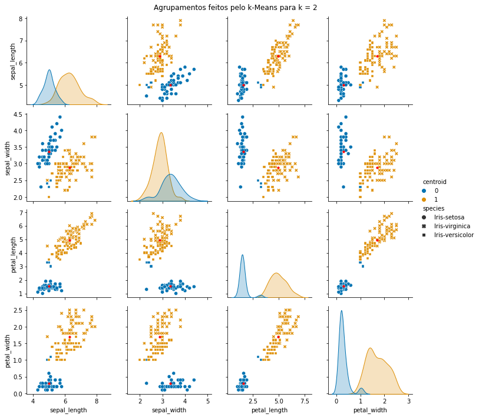

```python
pairs = sns.PairGrid(grouped, hue='centroid', palette='colorblind')
pairs.map_diag(sns.kdeplot, fill=True)
pairs.map_offdiag(sns.scatterplot, style=grouped['species'])
pairs.map_offdiag(plot_mean)

pairs.add_legend(title='',adjust_subtitles=True)
pairs.fig.subplots_adjust(top=0.95)
pairs.fig.suptitle('Agrupamentos feitos pelo k-Means para k = {}'.format(k))

plt.show()
```

Visualmente, o agrupamento parece ter separado a Iris setosa das demais. Todos os pontos de formato correspondente à Iris setosa parecem pertencer ao mesmo grupo, enquanto os de outros formatos, com exceção de alguns, caíram no outro.

É evidente que os pontos de espécie Iris setosa estão mais separados das demais espécies que as outras, já que eles não se sobrepõem com outras espécies em nenhum dos pares, ao contrário da Iris virginica com a Iris versicolor. Estes resultados corroboram também as métricas absolutas observadas para a Iris setosa no algoritmo anterior, já que um conglomerado mais separado de dados seria classificado mais facilmente pelo k-NN também.

Num geral, os dados parecem ter sido classificados com alta acurácia em Iris setosa e outros, mas para ter uma noção melhor de como os centroides se relacionam às classes reais podemos fazer uma espécie de matriz de confusão:

```python
idx = ['Iris-setosa','Outros']

confusion = pd.DataFrame(0, index = idx, columns = [0,1])

for _, row in grouped.iterrows():
    species = row['species'] if row['species'] == 'Iris-setosa' else 'Outros'
    centroid = row['centroid']
    confusion.loc[species,centroid] += 1

ordered_idx = [confusion[column].idxmax() for column in confusion]
confusion = confusion.loc[ordered_idx,:]

confusion.index = pd.MultiIndex.from_product([['Espécie'],ordered_idx])
confusion.columns = pd.MultiIndex.from_product([['Centroide'],[0,1]])
display(confusion)
```

|  |  | Centroide 0 | Centroide 1 |
| --- | --- | --- | --- |
| Espécie | Iris-setosa | 50 | 0 |
|  | Outros | 3 | 97 |

De fato, realmente há uma correspondência entre os centroides e a classificação como Iris setosa ou outros, e os resultados são visíveis pela tabela. Apenas três instâncias foram identificadas erroneamente, e as três foram falsos-positivos para Iris setosa. Assim, considerando uma correspondência entre os centroides e a presença de Iris setosa, o agrupamento atingiu uma acurácia de $98\%$ e uma precisão de cerca de $94,3\%$, e uma revocação de $100\%$ já que não houve falsos-negativos. Considerando que o agrupamento não tinha informação nenhuma sobre as espécies anteriormente, fora as métricas das flores, são resultados surpreendentes.

Vamos agora observar os resultados do algoritmo para k = 3. Após observar os dados no gráfico anterior, as instâncias de Iris virginica e Iris versicolor parecem se sobrepor mais, então será interessante ver como o algoritmo vai lidar com essa sobreposição. Vamos repetir o mesmo processo mudando apenas o valor de k:

```python
k = 3

iris_all_X = iris_all.loc[:,iris_all.columns != 'species']
iris_all_y = iris_all.loc[:,'species']

grouped_X, centroids = kMeans(k,iris_all_X)

grouped = pd.concat([grouped_X, iris_all_y], axis=1)

centroids.columns.name = 'k = {}'.format(k)

centroids
```

| k = 3 centroid | sepal_length | sepal_width | petal_length | petal_width |
| --- | --- | --- | --- | --- |
| 0 | 5.901613 | 2.748387 | 4.393548 | 1.433871 |
| 1 | 5.006000 | 3.418000 | 1.464000 | 0.244000 |
| 2 | 6.850000 | 3.073684 | 5.742105 | 2.071053 |

O gráfico seguinte será um plot de pares, de modo semelhante ao anterior. Porém dessa vez haverá três cores, pois três grupos foram gerados. Considerando um desempenho perfeito, se espera que haja uma correspondência de um pra um entre as cores, que representam os grupos, e as formas, que representam as espécies:

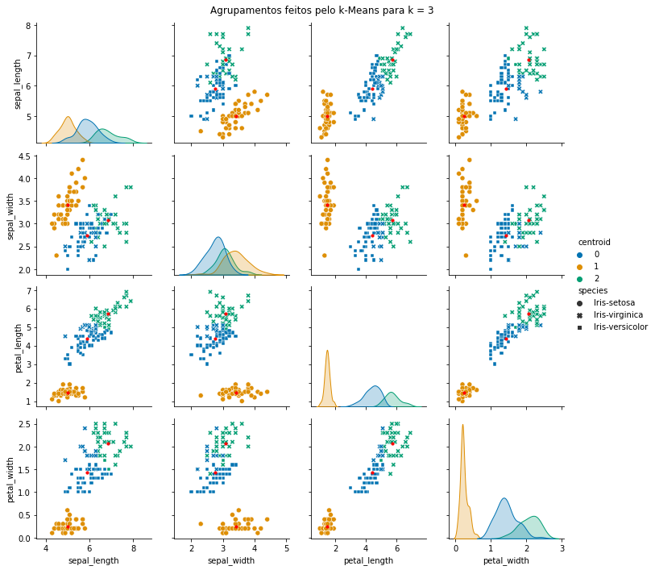

```python
pairs = sns.PairGrid(grouped, hue='centroid', palette='colorblind')

pairs.map_diag(sns.kdeplot, fill=True)
pairs.map_offdiag(sns.scatterplot, style=grouped['species'])
pairs.map_offdiag(plot_mean)

pairs.add_legend(title='',adjust_subtitles=True)
pairs.fig.subplots_adjust(top=0.95)
pairs.fig.suptitle('Agrupamentos feitos pelo k-Means para k = {}'.format(k))

plt.show()
```

Embora não seja uma correspondência exata, os grupos visualmente parecem corresponder em maioria a uma espécie cada um. A Iris setosa, novamente, se destaca entre as demais, com o seu grupo aparentando formar uma coincidência exata com a espécie, sem falsos positivos nem negativos.

Os outros grupos, no entanto, têm interseções visíveis nas duas espécies restantes. Isso é mais visível nos pares contendo a largura e comprimento das pétalas. O grupo cuja maioria é de Iris versicolor contém uma quantidade considerável de Iris virginica, enquanto o grupo cuja maioria é de Iris virginica tem uma pequena quantidade de Iris versicolor. De qualquer forma, é evidente que cada grupo tem uma maioria considerável pertencente a uma espécie definida.

De fato, conforme esperado, houve interseções entre a Iris virginica e Iris versicolor. Como houve uma correspondência entre grupos e espécies, podemos fazer a matriz de confusão também para estes dados, para visualizar melhor as métricas de cada grupo:

```python
idx = ['Iris-setosa','Iris-versicolor','Iris-virginica']
confusion = pd.DataFrame(0, index = idx, columns = [0,1,2])

for _, row in grouped.iterrows():
    confusion.loc[row['species'], row['centroid']] += 1

ordered_idx = [confusion[column].idxmax() for column in confusion]
confusion = confusion.loc[ordered_idx,:]

confusion.index = pd.MultiIndex.from_product([['Espécie'],ordered_idx])
confusion.columns = pd.MultiIndex.from_product([['Centroide'],[0,1,2]])
display(confusion)
```

|  |  | Centroide 0 | Centroide 1 | Centroide 2 |
| --- | --- | --- | --- | --- |
| Espécie | Iris-versicolor | 48 | 0 | 2 |
|  | Iris-setosa | 0 | 50 | 0 |
|  | Iris-virginica | 14 | 0 | 36 |

Observando as quantidades de cada espécie em cada grupo, realmente houve uma correspondência entre grupos e espécies, embora não tão exata quanto para k = 2. A acurácia geral do agrupamento foi de cerca de $89,3\%$, um resultado considerável, considerando que foi uma classificação de três grupos diferentes. Além disso, nesse caso as classes estão divididas igualmente em 50 instâncias cada, então há menos discrepâncias de tamanho em cada classe que a acurácia não seria capaz de captar.

A Iris setosa, conforme observado, foi a que foi melhor classificada, tendo uma correspondência de um para um com seu grupo, sem falsos positivos nem falsos negativos. As outras espécies, no entanto, apresentaram numericamente o que pôde ser observado no gráfico anterior. Uma quantidade considerável de Iris virginica, 14 das 50 instâncias, foram identificadas como Iris versicolor, enquanto duas Iris versicolor foram identificadas como Iris virginica.

Isso indica uma alta taxa de falsos negativos para Iris virginica, cuja revocação é de cerca de $72\%$, e uma alta taxa de falsos positivos para Iris versicolor, cuja precisão é de $78\%$. Esses resultados corroboram as métricas obtidas pelo k-NN para estas espécies, indicando que a tendência de cada uma a falsos positivos ou negativos talvez se relacione mais com a distribuição dos pontos no espaço que com o algoritmo usado em si.

**Obs:** Como o k-Means escolhe os primeiros centroides aleatoriamente, execuções diferentes podem mudar a ordem dos centroides de cada grupo e podem convergir para grupos ligeiramente distintos, com um ponto a mais ou a menos. Assim, embora as explicações tenham sido dadas sem definir que centroide específico foi atribuído a cada grupo, ainda há a chance de que as matrizes de confusão sejam ligeiramente diferentes e com isso o cálculo das métricas também seja. As métricas foram calculadas levando em consideração a última execução do notebook antes do envio.

## Conclusão

Com este trabalho, foi possível observar a forte aplicação de algoritmos de aprendizado à análise de dados, bem como aprender aspectos práticos da implementação do k-Nearest Neighbors e do k-Means, ambos baseados em distâncias euclidianas. Quanto a estes algoritmos, foi possível observar como, apesar de terem aplicações distintas, seus resultados muitas vezes fizeram com que se chegasse, diretamente ou não, às mesmas conclusões sobre os dados. Por fim, foi possível com o uso dos algoritmos observar como a base de dados Iris se comporta, bem como realizar previsões sobre seus valores.